# Chapter 3: Logistic Regression

*Describe the work you have done this week and summarize your learning.*

- After last weeks fiasco I think I got a hang out of this course topic. Last week I made multiple mistakes which I understood at the peer review stage. First mistake was not to follow the instructions that well. I missed many things in the middle and I didn’t understand the analysis part that much. This week I finally got some of the things.
- Box charts I haven’t seen before. It took me a while to understand them and I did manage to understand. Thanks to YouTube practical explanations, they are easy and powerful but are explained really weirdly on Wiki and at this course.
- This time I started to understand some of the topics of statistical analysis. I understood coefficient, p-value, deviance. Last time I was so confused about them.New for this week is the odds ratio and the whole logistic regression basics.
- I still didn’t understand everything, but compared to last week. This time I even understand what I need to do and how to interpret the main values.

```r
date()
```

```
## [1] "Mon Nov 22 02:30:19 2021"
```

```r
library(ggplot2)
library(dplyr)
library(boot)

url <- "https://github.com/rsund/IODS-project/raw/master/data"
url_alc <- paste(url, "alc.csv", sep = "/")

alc <- read.csv(url_alc, header = TRUE)
dim(alc)
```

```
## [1] 370  51
```

```r
colnames(alc)
```

```
##  [1] "school"     "sex"        "age"        "address"    "famsize"
##  [6] "Pstatus"    "Medu"       "Fedu"       "Mjob"       "Fjob"
## [11] "reason"     "guardian"   "traveltime" "studytime"  "schoolsup"
## [16] "famsup"     "activities" "nursery"    "higher"     "internet"
## [21] "romantic"   "famrel"     "freetime"   "goout"      "Dalc"
## [26] "Walc"       "health"     "n"          "id.p"       "id.m"
## [31] "failures"   "paid"       "absences"   "G1"         "G2"
## [36] "G3"         "failures.p" "paid.p"     "absences.p" "G1.p"
## [41] "G2.p"       "G3.p"       "failures.m" "paid.m"     "absences.m"
## [46] "G1.m"       "G2.m"       "G3.m"       "alc_use"    "high_use"
## [51] "cid"
```

This joined data set contains alcohol consumption of students in two Portuguese schools. Data was collected using school reports and questionnaires. Data set contains 370 results from 29 sets of data.

1. school - student’s school (binary: ‘GP’ - Gabriel Pereira or ‘MS’ - Mousinho da Silveira)
2. sex - student’s sex (binary: ‘F’ - female or ‘M’ - male)
3. age - student’s age (numeric: from 15 to 22)
4. address - student’s home address type (binary: ‘U’ - urban or ‘R’ - rural)
5. famsize - family size (binary: ‘LE3’ - less or equal to 3 or ‘GT3’ - greater than 3)
6. Pstatus - parent’s cohabitation status (binary: ‘T’ - living together or ‘A’ - apart)
7. Medu - mother’s education (numeric: 0 - none, 1 - primary education (4th grade), 2 - 5th to 9th grade, 3 - secondary education or 4 - higher education)
8. Fedu - father’s education (numeric: 0 - none, 1 - primary education (4th grade), 2 - 5th to 9th grade, 3 - secondary education or 4 - higher education)
9. Mjob - mother’s job (nominal: ‘teacher’, ‘health’ care related, civil ‘services’ (e.g. administrative or police), ‘at_home’ or ‘other’)
10. Fjob - father’s job (nominal: ‘teacher’, ‘health’ care related, civil ‘services’ (e.g. administrative or police), ‘at_home’ or ‘other’)
11. reason - reason to choose this school (nominal: close to ‘home’, school ‘reputation’, ‘course’ preference or ‘other’)
12. guardian - student’s guardian (nominal: ‘mother’, ‘father’ or ‘other’)
13. traveltime - home to school travel time (numeric: 1 - <15 min., 2 - 15 to 30 min., 3 - 30 min. to 1 hour, or 4 - >1 hour)
14. studytime - weekly study time (numeric: 1 - <2 hours, 2 - 2 to 5 hours, 3 - 5 to 10 hours, or 4 - >10 hours)
15. schoolsup - extra educational support (binary: yes or no)
16. famsup - family educational support (binary: yes or no)
17. activities - extra-curricular activities (binary: yes or no)
18. nursery - attended nursery school (binary: yes or no)
19. higher - wants to take higher education (binary: yes or no)
20. internet - Internet access at home (binary: yes or no)
21. romantic - with a romantic relationship (binary: yes or no)
22. famrel - quality of family relationships (numeric: from 1 - very bad to 5 - excellent)
23. freetime - free time after school (numeric: from 1 - very low to 5 - very high)
24. goout - going out with friends (numeric: from 1 - very low to 5 - very high)
25. Dalc - workday alcohol consumption (numeric: from 1 - very low to 5 - very high)
26. Walc - weekend alcohol consumption (numeric: from 1 - very low to 5 - very high)
27. health - current health status (numeric: from 1 - very bad to 5 - very good)
28. alc_use - The average of Dalc and Walc
29. high_use - TRUE if alc_use is higher than 2 and FALSE otherwise

### 3. Personal hypothesis

I chose the following four variables for personal hypothesis on alcohol consumption: 1. romantic 2. higher 3. internet 4. schoolsup

My hypothesis is that a romantic relationship and higher education decreases the alcohol consumption, but lacking the support from school and not having internet connection at home (need to stay long at campus) increases the alcohol consumption.

### 4. Personal hypothesis on numbers

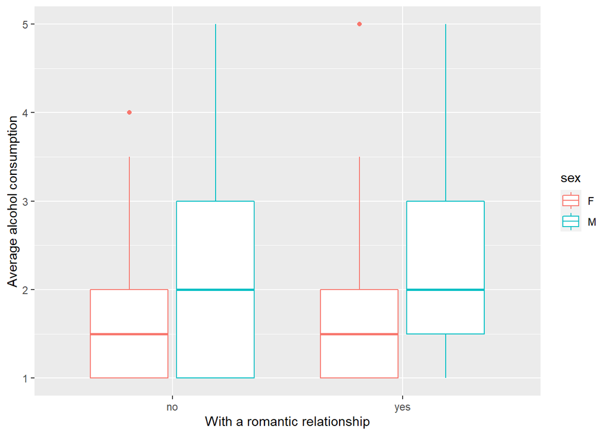

```r
phPlot <- ggplot(alc, aes(x = romantic, y = alc_use, col = sex))
phPlot + geom_boxplot() +
          ylab("Average alcohol consumption") +
          xlab("With a romantic relationship")
```

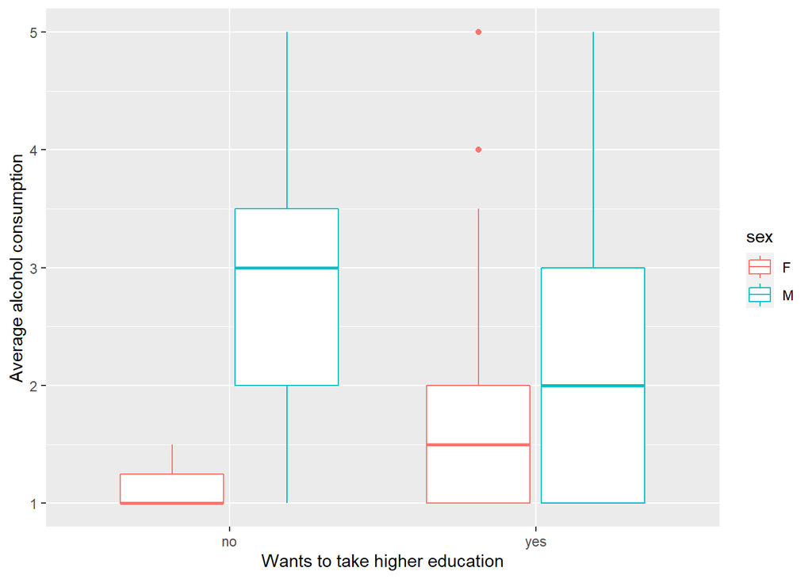

```r
phPlot <- ggplot(alc, aes(x = higher, y = alc_use, col = sex))
phPlot + geom_boxplot() +
        ylab("Average alcohol consumption") +
        xlab("Wants to take higher education")
```

As assumed the higher education lowered the alcohol consumption, with males. But the alcohol consumption on females who want to take higher education, is higher. Which is total opposite on my assumption.

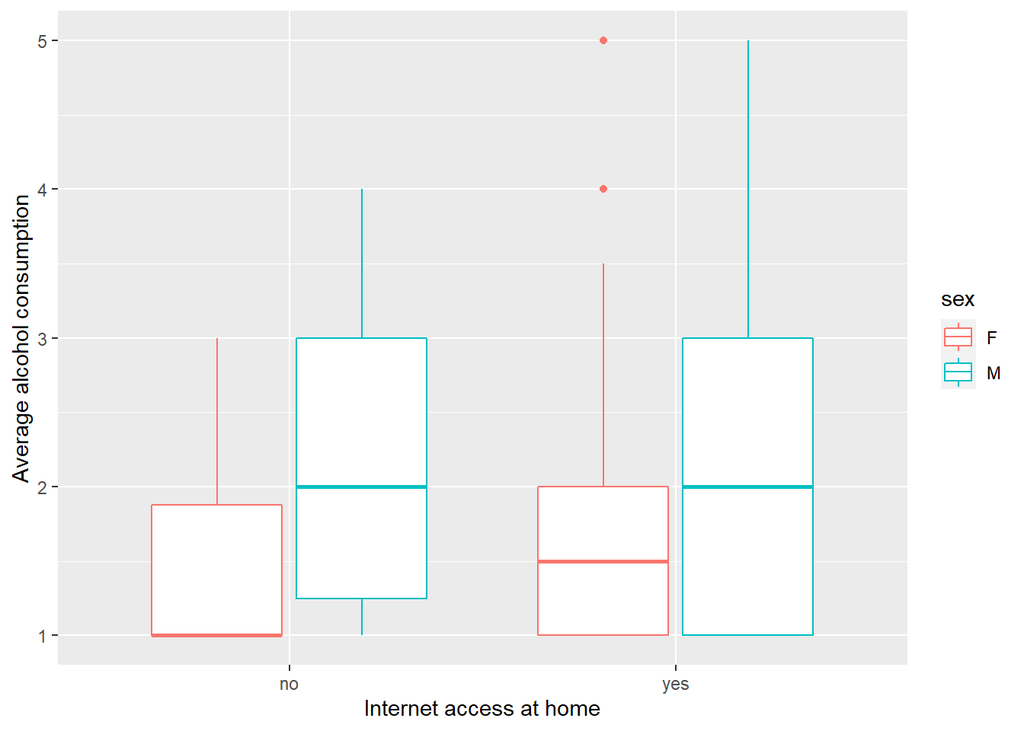

```r
phPlot <- ggplot(alc, aes(x = internet, y = alc_use, col = sex))
phPlot + geom_boxplot() +
        ylab("Average alcohol consumption") +
        xlab("Internet access at home")
```

Here is second surprising results. Internet increases alcohol consumption of female persons. With males the median staid the same, but the consumption got more dispersed on the maximum and lower ends.

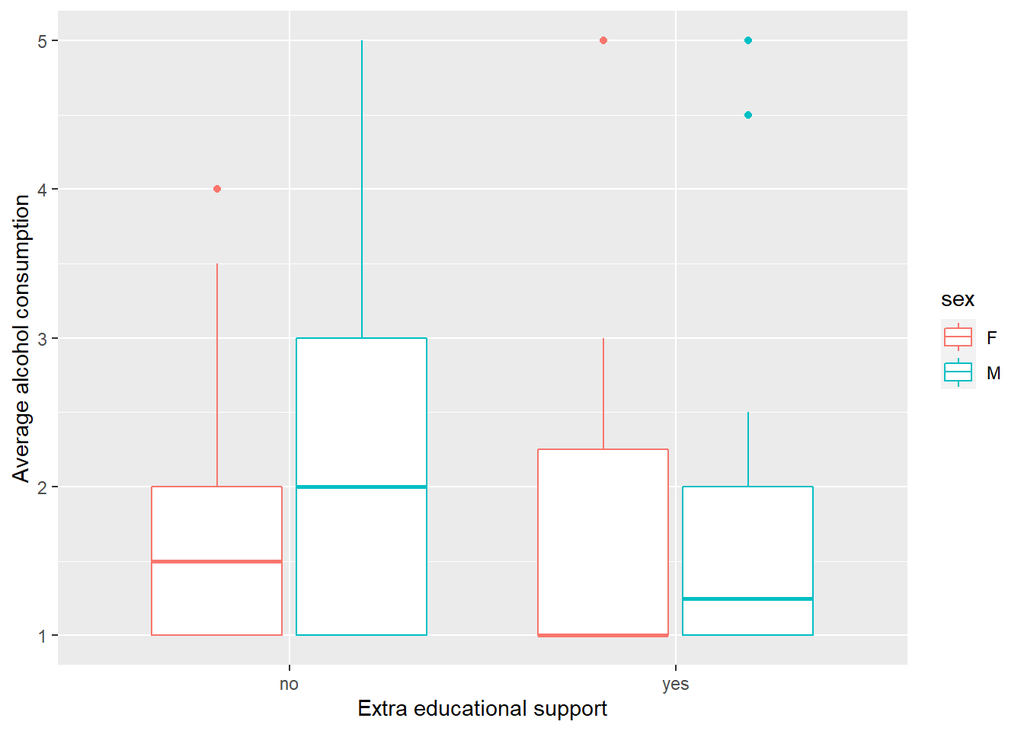

```r
phPlot1 <- ggplot(alc, aes(x = schoolsup, y = alc_use, col = sex))
phPlot1 + geom_boxplot() +
        ylab("Average alcohol consumption") +
        xlab("Extra educational support")
```

This was the only assumption which went as I thought. More educational support students get, the lower is their alcohol consuption. It was a larger drop on both genders, but I assumed it was so.

### 5. Logistic Regression

```r
m <- glm(high_use ~ romantic + higher + internet + schoolsup, data = alc, family = "binomial")
summary(m)
```

```
##
## Call:
## glm(formula = high_use ~ romantic + higher + internet + schoolsup,
##     family = "binomial", data = alc)
##
## Deviance Residuals:
##     Min       1Q   Median       3Q      Max
## -1.2857  -0.8807  -0.7814   1.5065   1.7737
##
## Coefficients:
##              Estimate Std. Error z value Pr(>|z|)
## (Intercept)    0.2511     0.5980   0.420    0.675
## romanticyes   -0.2831     0.2547  -1.112    0.266
## higheryes     -1.2242     0.5263  -2.326    0.020 *
## internetyes    0.2261     0.3289   0.688    0.492
## schoolsupyes  -0.3105     0.3574  -0.869    0.385
## ---
## Signif. codes:  0 '***' 0.001 '**' 0.01 '*' 0.05 '.' 0.1 ' ' 1
##
## (Dispersion parameter for binomial family taken to be 1)
##
##     Null deviance: 452.04  on 369  degrees of freedom
## Residual deviance: 444.76  on 365  degrees of freedom
## AIC: 454.76
##
## Number of Fisher Scoring iterations: 4
```

In the summary we can see that the variable higher is the only one which p-value is under 5%, so it can be considered as a significant. Now we can confirm on the charts on my personal hypothesis that the only really significant chart was indeed the variable higher. From the deviance we can see that high alcohol usage is not that common within 15-22 years old, therefore it is more on the minimum side. But there are variation between min and max.

```r
OR <- coef(m) %>% exp
CI <- confint(m) %>% exp
cbind(OR, CI)
```

```
##                     OR     2.5 %    97.5 %
## (Intercept)  1.2854900 0.3969561 4.2627835
## romanticyes  0.7534579 0.4527659 1.2317868
## higheryes    0.2939864 0.1007957 0.8226494
## internetyes  1.2537265 0.6707657 2.4542330
## schoolsupyes 0.7330743 0.3506197 1.4390072
```

As you can see from odds ratio the variable higher is the only one which is really dispersed. The other variables are quite static, without that much variation. The coefficient intervals show that there are big chunks of values are in the same area, but there are this small set of data which is dispersed away from each other.

### 6. Explore the predictive power of you model

```r
prob <- predict(m, type = "response")
alc <- mutate(alc, probability = prob)
alc <- mutate(alc, prediction = probability > 0.5)

table(high_use = alc$high_use, prediction = alc$prediction)
```

```
##         prediction
## high_use FALSE TRUE
##    FALSE   252    7
##    TRUE    103    8
```

```r
table(high_use = alc$high_use, prediction = alc$prediction) %>%
        prop.table() %>%
        addmargins()
```

```
##         prediction
## high_use      FALSE       TRUE        Sum
##    FALSE 0.68108108 0.01891892 0.70000000
##    TRUE  0.27837838 0.02162162 0.30000000
##    Sum   0.95945946 0.04054054 1.00000000
```

```r
# define a loss function (mean prediction error)
loss_func <- function(class, prob) {
  n_wrong <- abs(class - prob) > 0.5
  mean(n_wrong)
}

loss_func(class = alc$high_use, prob = alc$probability)
```

```
## [1] 0.2972973
```

### 7. Bonus

```r
cv <- cv.glm(data = alc, cost = loss_func, glmfit = m, K = 10)
cv$delta[1]
```

```
## [1] 0.3
```